# Analysis of Wine Quality based on Chemical Ingredients

# Abstract

In the present paper I am going to analyze the impact of chemical properties of a wine to its quality. Based on my analyses, I am going to develop a model to predict the quality of wine based on its chemical ingredients.

# Introduction

My analyses in the present paper are based on a data set which contains 1.599 red wines with 11 variables on the chemical properties of the wine. In addition to those 11 variables, each wines’ quality has been assessed and added as a 12th data column. Obviously, the quality of wine is subjective, in the case of the available data, the quality of each wine has been rated by at least 3 wine experts at a sclae between 0 (very bad) and 10 (very excellent).

The objectives of the analyses the following: 1) Answer the question: Which chemical properties influence the quality of red wines? 2) Develop a model to predict the quality of a wine based on the chemical properties.

In the next sections I am going to start with univariat analysis on each of the 11 chemical components of the data set.

# Univariat Analysis of Chemical Components

In this section I’m doing some univariat analyses on a few selected chemical components provided within the data set. However, first of all I will start of with an overview of all availalbe variables and some basic statistical information.

## Overview of Variables

Here is a list of all variables in the data set and some basic statistical information.

```
## 'data.frame':    1599 obs. of  13 variables:
##  $ X                   : int  1 2 3 4 5 6 7 8 9 10 ...
##  $ fixed.acidity       : num  7.4 7.8 7.8 11.2 7.4 7.4 7.9 7.3 7.8 7.5 ...
##  $ volatile.acidity    : num  0.7 0.88 0.76 0.28 0.7 0.66 0.6 0.65 0.58 0.5 ...
##  $ citric.acid         : num  0 0 0.04 0.56 0 0 0.06 0 0.02 0.36 ...
##  $ residual.sugar      : num  1.9 2.6 2.3 1.9 1.9 1.8 1.6 1.2 2 6.1 ...
##  $ chlorides           : num  0.076 0.098 0.092 0.075 0.076 0.075 0.069 0.065 0.073 0.071 ...
##  $ free.sulfur.dioxide : num  11 25 15 17 11 13 15 15 9 17 ...
##  $ total.sulfur.dioxide: num  34 67 54 60 34 40 59 21 18 102 ...
##  $ density             : num  0.998 0.997 0.997 0.998 0.998 ...
##  $ pH                  : num  3.51 3.2 3.26 3.16 3.51 3.51 3.3 3.39 3.36 3.35 ...
##  $ sulphates           : num  0.56 0.68 0.65 0.58 0.56 0.56 0.46 0.47 0.57 0.8 ...
##  $ alcohol             : num  9.4 9.8 9.8 9.8 9.4 9.4 9.4 10 9.5 10.5 ...
##  $ quality             : int  5 5 5 6 5 5 5 7 7 5 ...
```

```
##        X          fixed.acidity   volatile.acidity  citric.acid
##  Min.   :   1.0   Min.   : 4.60   Min.   :0.1200   Min.   :0.000
##  1st Qu.: 400.5   1st Qu.: 7.10   1st Qu.:0.3900   1st Qu.:0.090
##  Median : 800.0   Median : 7.90   Median :0.5200   Median :0.260
##  Mean   : 800.0   Mean   : 8.32   Mean   :0.5278   Mean   :0.271
##  3rd Qu.:1199.5   3rd Qu.: 9.20   3rd Qu.:0.6400   3rd Qu.:0.420
##  Max.   :1599.0   Max.   :15.90   Max.   :1.5800   Max.   :1.000
##  residual.sugar     chlorides       free.sulfur.dioxide
##  Min.   : 0.900   Min.   :0.01200   Min.   : 1.00
##  1st Qu.: 1.900   1st Qu.:0.07000   1st Qu.: 7.00
##  Median : 2.200   Median :0.07900   Median :14.00
##  Mean   : 2.539   Mean   :0.08747   Mean   :15.87
##  3rd Qu.: 2.600   3rd Qu.:0.09000   3rd Qu.:21.00
##  Max.   :15.500   Max.   :0.61100   Max.   :72.00
##  total.sulfur.dioxide    density             pH          sulphates
##  Min.   :  6.00       Min.   :0.9901   Min.   :2.740   Min.   :0.3300
##  1st Qu.: 22.00       1st Qu.:0.9956   1st Qu.:3.210   1st Qu.:0.5500
##  Median : 38.00       Median :0.9968   Median :3.310   Median :0.6200
##  Mean   : 46.47       Mean   :0.9967   Mean   :3.311   Mean   :0.6581
##  3rd Qu.: 62.00       3rd Qu.:0.9978   3rd Qu.:3.400   3rd Qu.:0.7300
##  Max.   :289.00       Max.   :1.0037   Max.   :4.010   Max.   :2.0000
##     alcohol         quality
##  Min.   : 8.40   Min.   :3.000
##  1st Qu.: 9.50   1st Qu.:5.000
##  Median :10.20   Median :6.000
##  Mean   :10.42   Mean   :5.636
##  3rd Qu.:11.10   3rd Qu.:6.000
##  Max.   :14.90   Max.   :8.000
```

## Univariate Plots Section

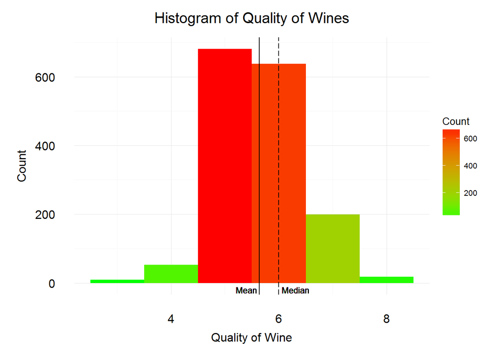

### Fixed Acidity

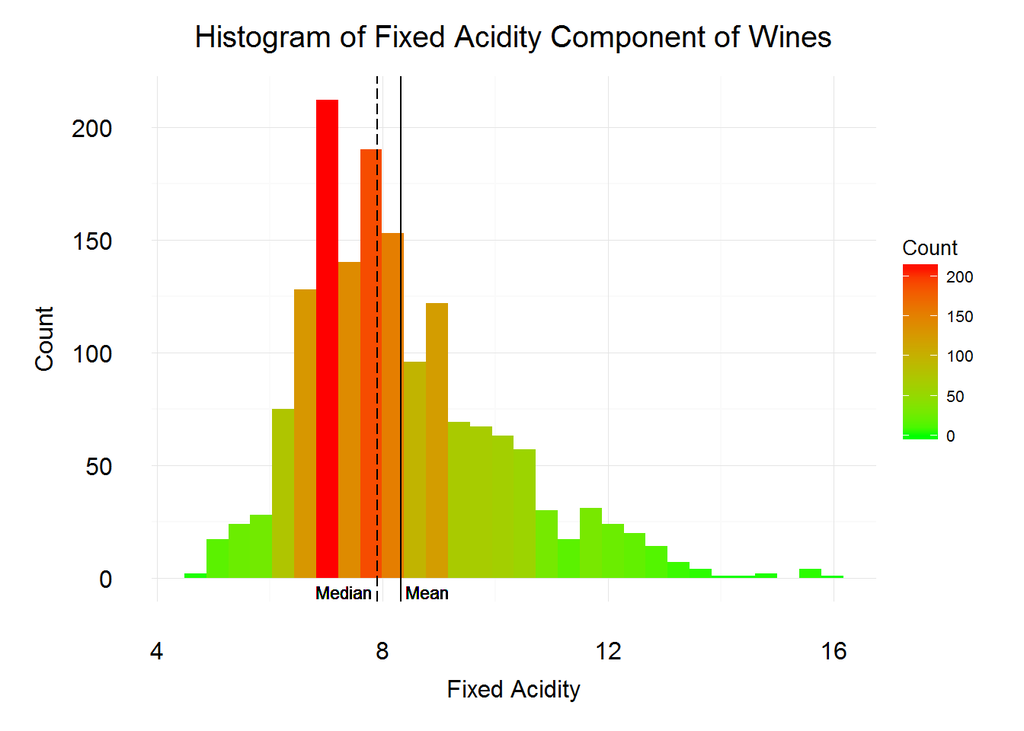

```
##    Min. 1st Qu.  Median    Mean 3rd Qu.    Max.
##    4.60    7.10    7.90    8.32    9.20   15.90
```

**Fixed Acidity**: most acids involved with wine or fixed or nonvolatile (do not evaporate readily).

The majority of values of *Fixed Acidity* are between 6 and 9. This fact is supported by a median of 7.9 and a mean of 8.32. Apart from the main values centered around the median, there are some higher values between 12 and 16.

### Volatile Acidity

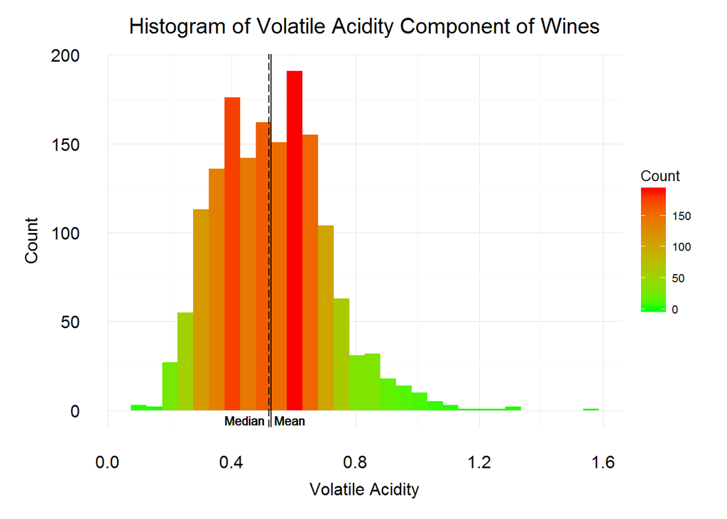

```
##    Min. 1st Qu.  Median    Mean 3rd Qu.    Max.
##  0.1200  0.3900  0.5200  0.5278  0.6400  1.5800
```

**Volatile Acidity**: the amount of acetic acid in wine, which at too high of levels can lead to an unpleasant, vinegar taste.

The majority of values of *Volatile Acidity* are between 0.35 and 0.65. This fact is supported by a median of 0.52 and a mean of 0.53. Apart from the main values centered around the median, there are some higher values between 1 and 1.6. As too high values of *Volatile Acidity* is assumend to make wine taste unpleasant, vingar I will later on investigate if this can be observed in this dataset as well.

### Ratio Volatile/Fixed Acidity

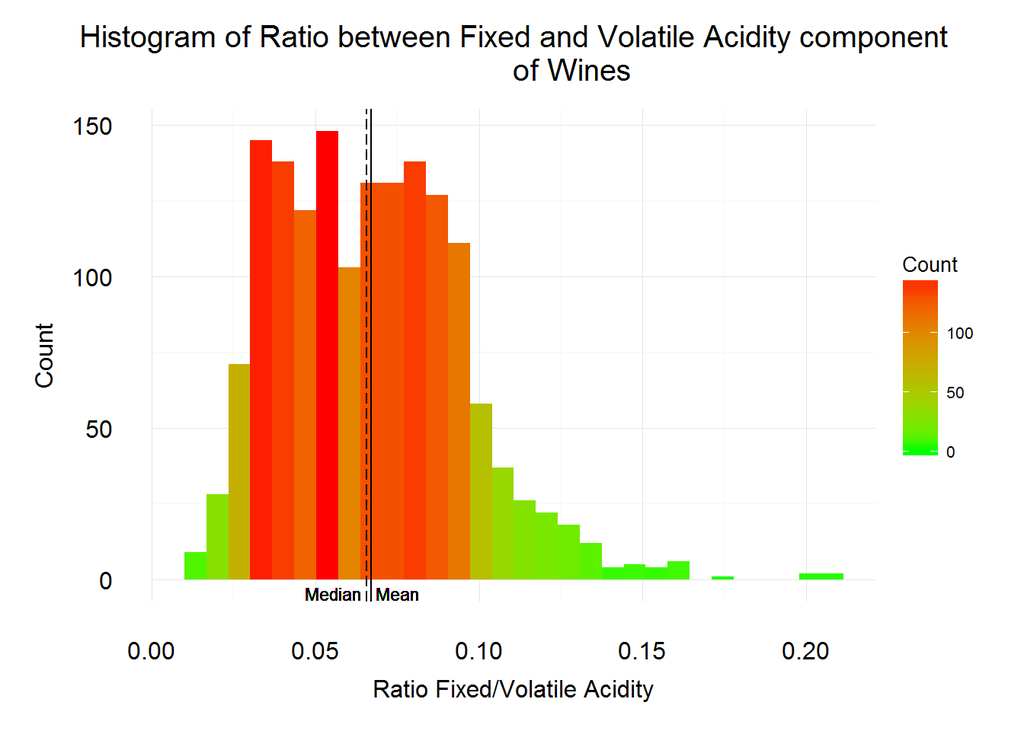

```
##    Min. 1st Qu.  Median    Mean 3rd Qu.    Max.
## 0.01348 0.04405 0.06569 0.06706 0.08581 0.20800
```

**Ratio Volatile/Fixed Acidity**: the ratio between *Volatile Acidity* and *Fixed Acidity*.

The values for *Ratio Volatile/Fixed Acidity* are strongly centered around the median of 0.066 and the mean of 0.067. In fact, about 82.5 % of values are in a range between 0.03 and 0.1. We can also see some outliers on the higher side of the the scale, raising up to valules above 0.2. In fact, there is slightly less than 1 % of values with a ratio higher than 0.15. …

### Citric Acid

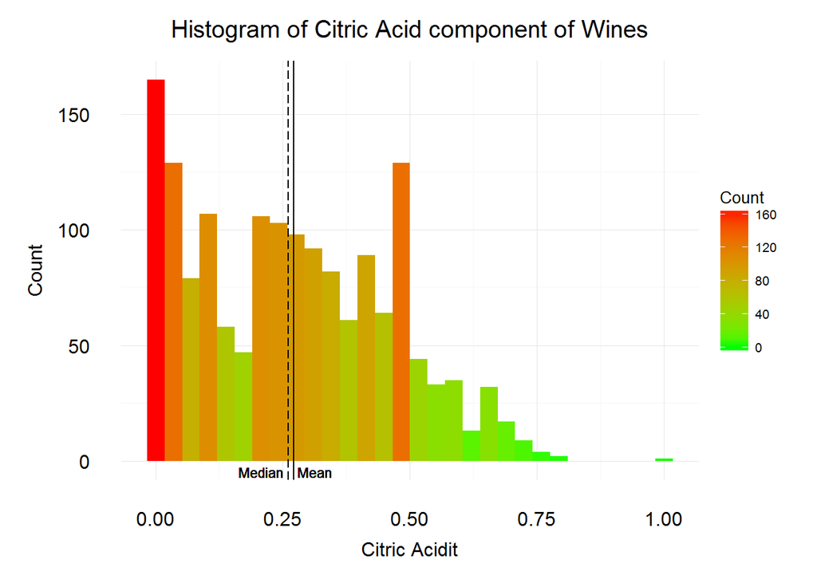

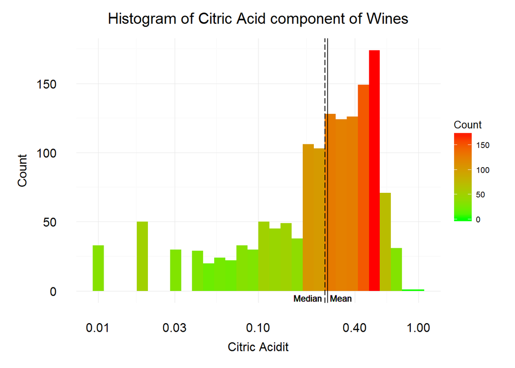

```
##    Min. 1st Qu.  Median    Mean 3rd Qu.    Max.
##   0.000   0.090   0.260   0.271   0.420   1.000
```

**Citric Acid**: found in small quantities, citric acid can add ‘freshness’ and flavor to wines.

To support the histogram on *Citric Acid* further, an additional histogram with log10 scaled x-axis is provided.

Number of Records where the amount of Citric Acid is 0:

```
## [1] 132
```

*Citric Acid* adds freshness and flavor to the taste of wine, so the quality of wines without this component might be impacted negativly. In total there are 132 Wines where this is true. Later on I will take a look at those wines and the related qualities.

Basic statistics where the amount of Citric Acid is >0:

```
##    Min. 1st Qu.  Median    Mean 3rd Qu.    Max.
##  0.0100  0.1400  0.2800  0.2954  0.4400  1.0000
```

### Residual Sugar

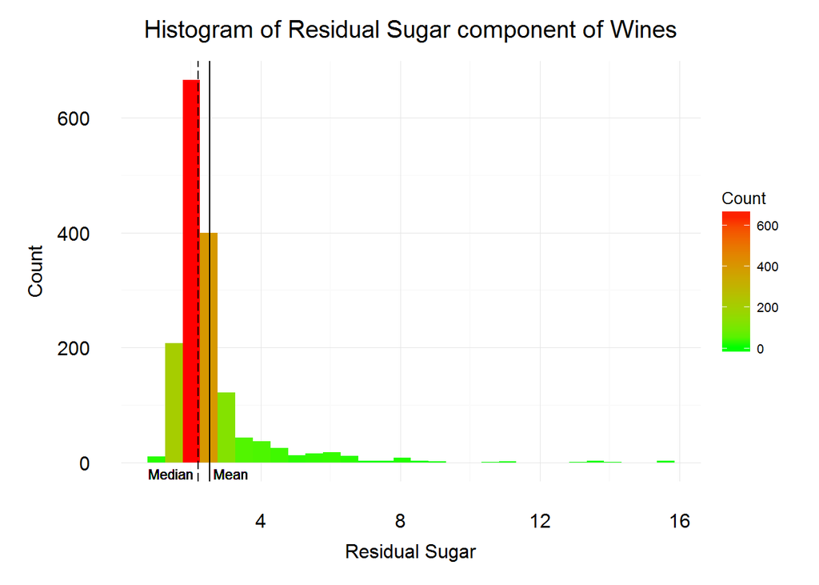

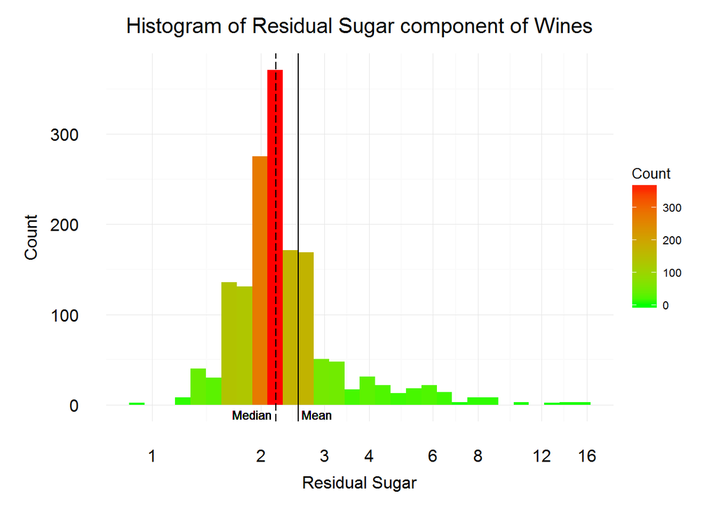

```
##    Min. 1st Qu.  Median    Mean 3rd Qu.    Max.
##   0.900   1.900   2.200   2.539   2.600  15.500
```

**Residual Sugar**: the amount of sugar remaining after fermentation stops, it’s rare to find wines with less than 1 gram/liter and wines with greater than 45 grams/liter are considered sweet

To support the histogram on *Residual Sugar* further, an additional histogram with log10 scaled x-axis is provided.

The majority of values of *Residual Sugar* are between 1 and 2.5. The median of 2.2 is within that spectrum. The mean of 2.54 is on the higher side of that range because almost 22 % of the values are higher than 2.5 and still more 1 % of values are higher than 8.5. The max value for “Residual Sugar” is at 15.5.

### Chlorides

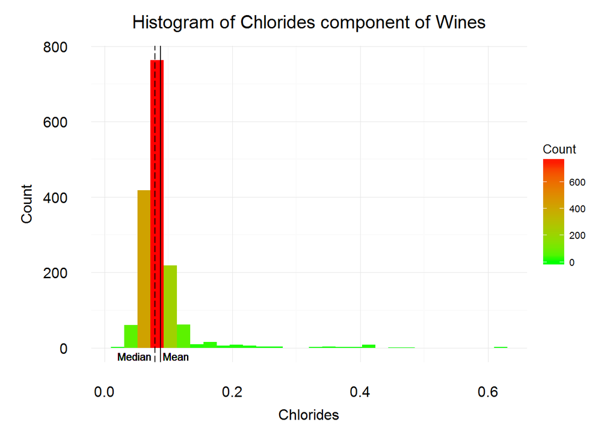

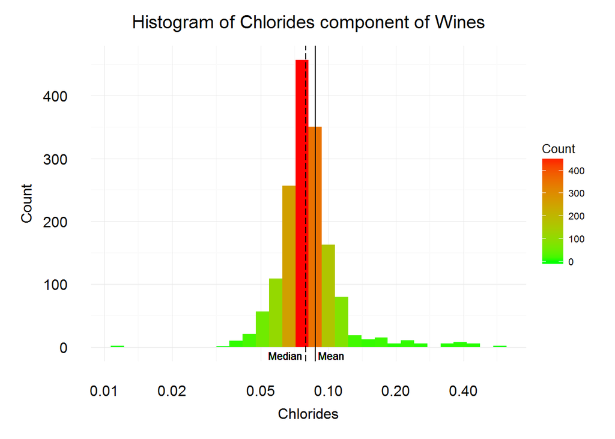

```
##    Min. 1st Qu.  Median    Mean 3rd Qu.    Max.
## 0.01200 0.07000 0.07900 0.08747 0.09000 0.61100
```

**Chlorides**: the amount of salt in the wine.

To support the histogram on *Chlorides* further, an additional histogram with log10 scaled x-axis is provided.

The majority of values of *Chlorides* are between 0.07 and 0.13. This fact is supported by a median of 0.079 and a mean of 0.087. Apart from the main values centered around the median, there are some values between 0 and 0.02, as well as between 0.2 and 0.611. However, 97.25 % of values are between 0.02 and 0.2.

### Free Sulfur Dioxide

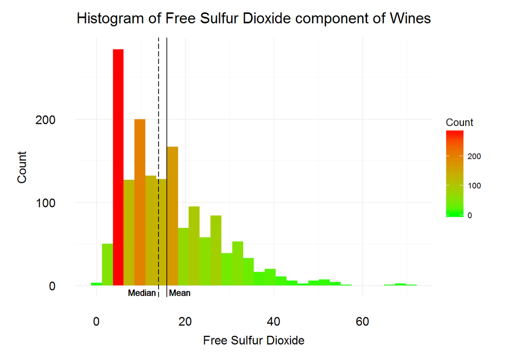

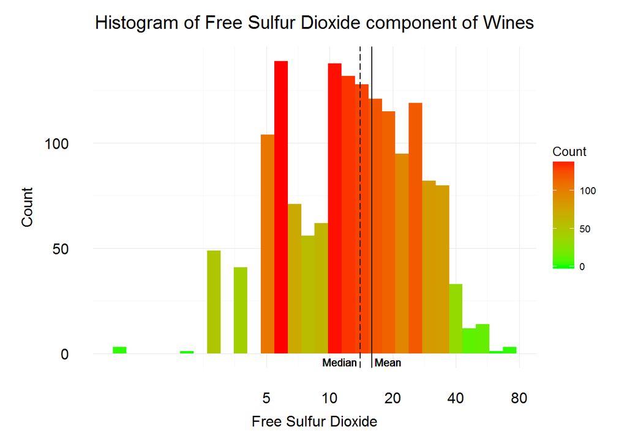

```
##    Min. 1st Qu.  Median    Mean 3rd Qu.    Max.
##    1.00    7.00   14.00   15.87   21.00   72.00
```

**Free Sulfur Dioxide**: the free form of SO2 exists in equilibrium between molecular SO2 (as a dissolved gas) and bisulfite ion; it prevents microbial growth and the oxidation of wine

To support the histogram on *Free Sulfur Dioxide* further, an additional histogram with log10 scaled x-axis is provided.

The majority of values of *Free Sulfur Dioxide* are between 5 and 40. This fact is supported by a median of 14 and a mean of 15.87. 85 % of values are within that range.

### Total Sulfur Dioxide

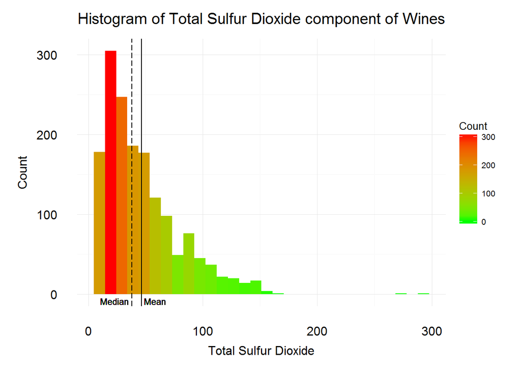

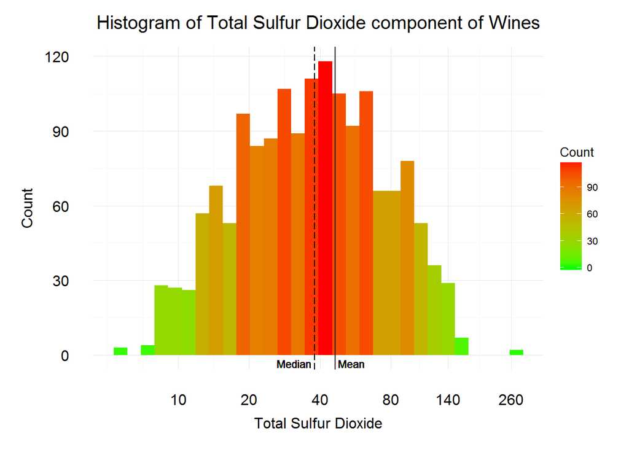

```
##    Min. 1st Qu.  Median    Mean 3rd Qu.    Max.
##    6.00   22.00   38.00   46.47   62.00  289.00
```

**Total Sulfur Dioxide**: amount of free and bound forms of S02; in low concentrations, SO2 is mostly undetectable in wine, but at free SO2 concentrations over 50 ppm, SO2 becomes evident in the nose and taste of wine.

To support the histogram on *Total Sulfur Dioxide* further, an additional histogram with log10 scaled x-axis is provided.

The majority of values of *Total Sulfur Dioxide* are between 20 and 80. This fact is supported by a median of 38 and a mean of 46.47. 77 % of values are within that range. Extreme outliers can be found on the higher side of the x-axis with value above 150, and a max value of even 289. However, most interesting seem to be values above 50, as from that value upwards the smell and taste of wine seem to be impacted.

```
## [1] 546
```

546 wine out of the dataset - that is slightly more than one third - has a value higher than 50 for *Total Sulfur Dioxide*.

### Ratio Sulfur Dioxide

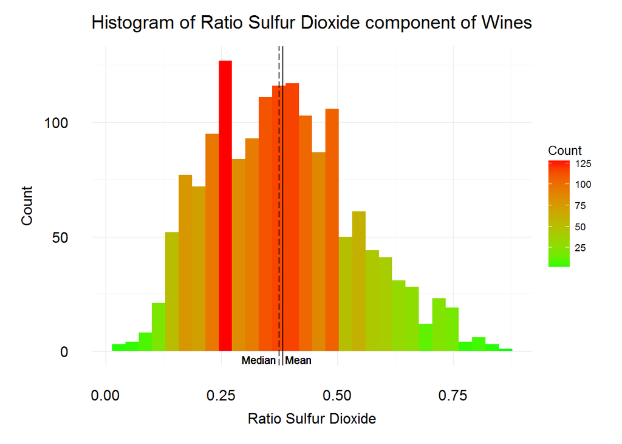

```
##    Min. 1st Qu.  Median    Mean 3rd Qu.    Max.
## 0.02273 0.25930 0.37500 0.38230 0.48480 0.85710
```

**Ratio Sulfur Dioxide**: Ratio between free sulfur dioxide and total sulfur dioxide provided in the data set. What this ratio is telling us is the proportion of free *Free Sulfur Dioxide* in the *Total Sulfur Dioxide*. The possible spectrum for this value is between 0 and 1.

Actually, in the histogram and values of the *Ratio Sulfur Dioxide* we can see that most of the data is between 0.10 and 0.5. Nevertheless, there are some values outside that range, especially on the higher side with values up to about 0.86 but also on the lower side with values going down to about 0.02. A big really difference between ratio values we see for different wines.

### Density

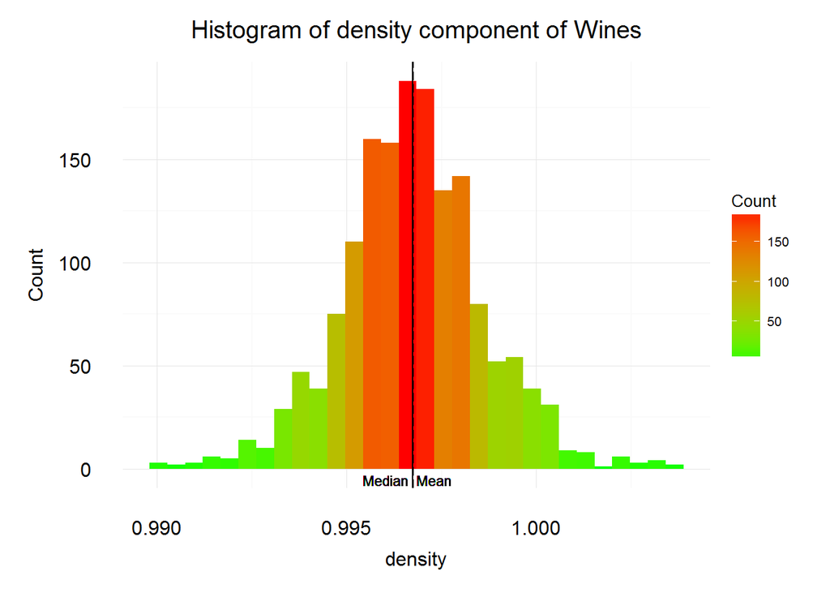

```
##    Min. 1st Qu.  Median    Mean 3rd Qu.    Max.
##  0.9901  0.9956  0.9968  0.9967  0.9978  1.0040
```

**Density**: the density of water is close to that of water depending on the percent alcohol and sugar content.

The majority of values of *Density* are between 0.995 and 1. This fact is supported by a median of 0.9968 and a mean of 0.9967. 79 % of values are within that range.

### pH-Value

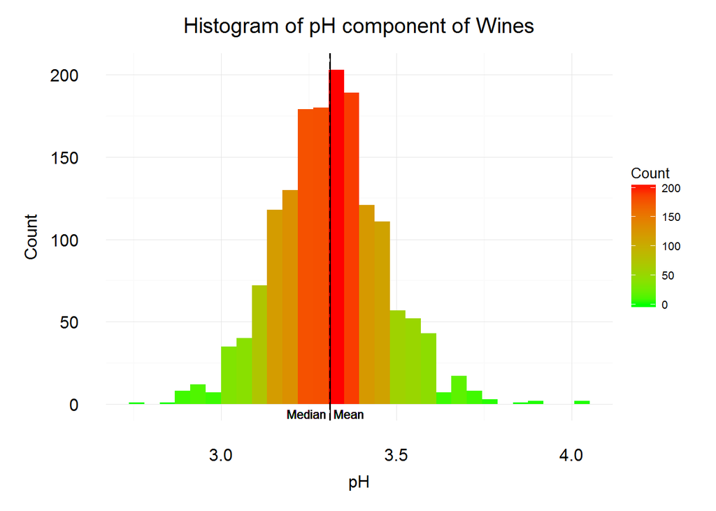

```
##    Min. 1st Qu.  Median    Mean 3rd Qu.    Max.
##   2.740   3.210   3.310   3.311   3.400   4.010
```

**pH**: describes how acidic or basic a wine is on a scale from 0 (very acidic) to 14 (very basic), 7 is neutral. Most wines are between 3-4 on the pH scale.

The majority of values of *pH* are between 3.1 and 3.5. This fact is supported by a median of 3.310 and a mean of 3.311. 80 % of values are within that range.

### Sulphates

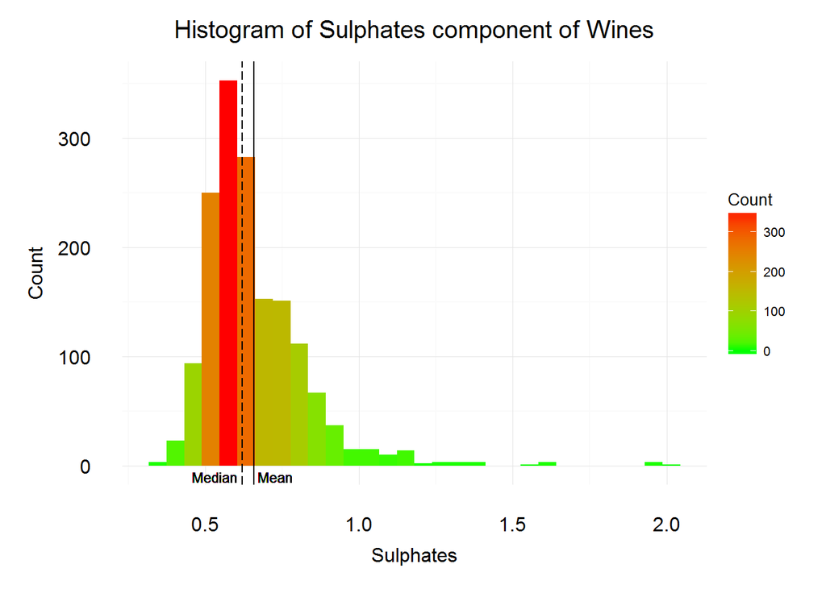

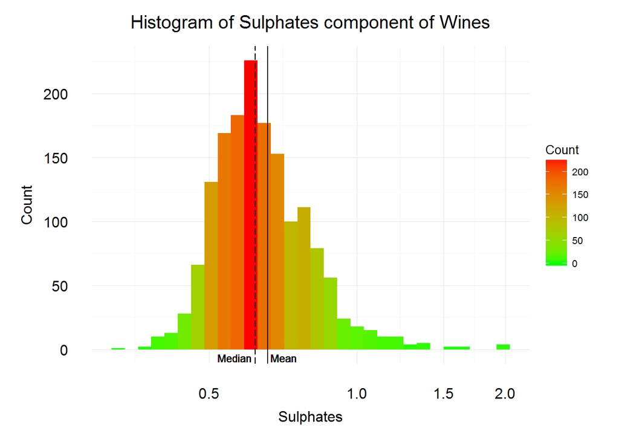

```
##    Min. 1st Qu.  Median    Mean 3rd Qu.    Max.
##  0.3300  0.5500  0.6200  0.6581  0.7300  2.0000
```

**Sulphates**: a wine additive which can contribute to sulfur dioxide gas (S02) levels, which acts as an antimicrobial and antioxidant.

To support the histogram on *Sulphates* further, an additional histogram with log10 scaled x-axis is provided.

The majority of values of *Sulphates* are between 0.4 and 0.8. This fact is supported by a median of 0.62 and a mean of 0.6581. 84 % of values are within that range. Some outliers can be found on the higher side of the x-axis with value above 1.5.

### Alcohol

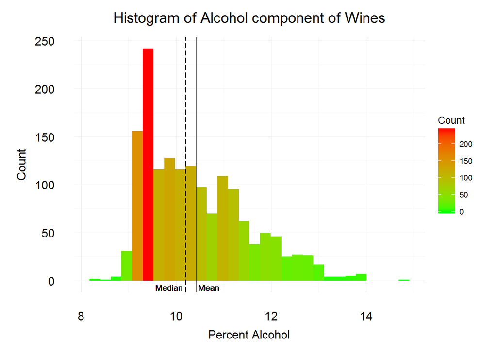

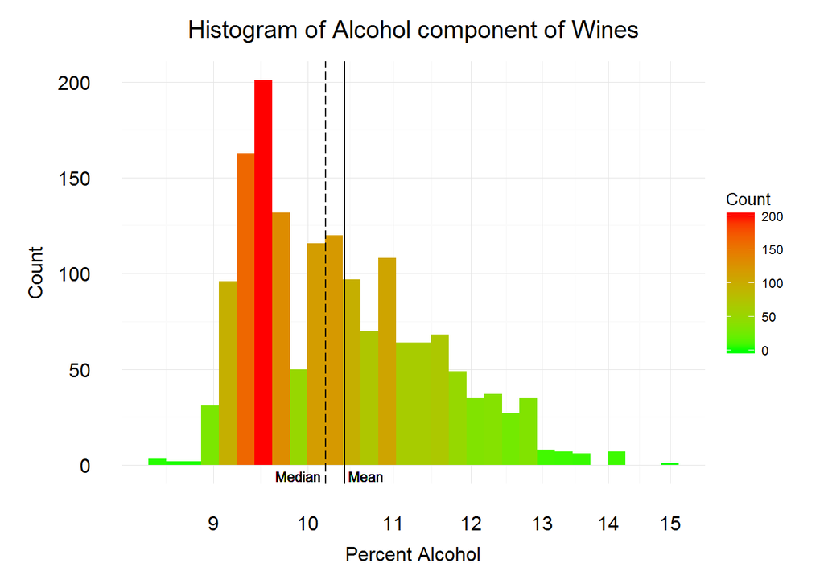

```
##    Min. 1st Qu.  Median    Mean 3rd Qu.    Max.
##    8.40    9.50   10.20   10.42   11.10   14.90
```

**Alcohol**: the percent alcohol content of the wine

To support the histogram on *Alcohol* further, an additional histogram with log10 scaled x-axis is provided.

The alcohol range is between 8.40 Vol.% and 14.90 Vol.%. A rather large portion of 55 % of the values is between 9 and 10.5 Vol.%. Within that range we can also see the median of 10.20 Vol.% and the mean of 10.42 Vol.%. However, a quite big portion of about 43 % of the values are from 10.5 Vol.% upwards.

A few wines have a high Vol.% value of 13 or higher. There are even 8 wines which do have a Vol.% Value of 14 and higher.

### Quality of Wine

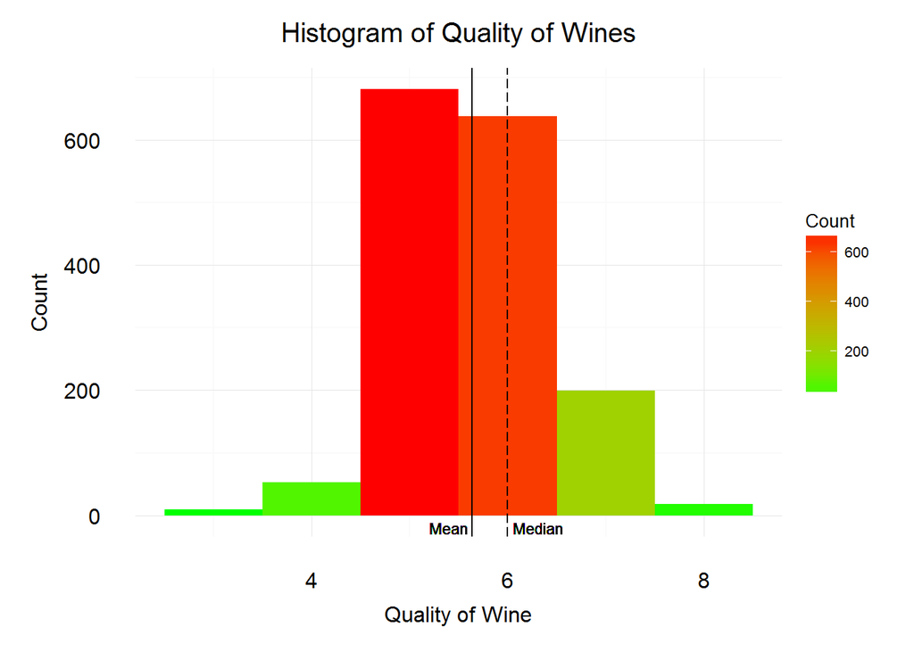

```
##    Min. 1st Qu.  Median    Mean 3rd Qu.    Max.
##   3.000   5.000   6.000   5.636   6.000   8.000
```

**Quality**: quality of wine (score between 0 and 10).

All values of *Quality* are between 3 and 8. The median *Quality* is 6 and a mean of 5.636. 82.5 % of values are either *Quality* 5 or 6.

## Univariate Analysis Section

### What is the structure of your dataset?

There are 1599 different wines in the dataset with 11 features (*fixed.acidity*, *volatile.acidity*, *citric.acid*, *residual.sugar*, *chlorides*, *free.sulfur.dioxide*, *total.sulfur.dioxide*, *density*, *pH*, *sulphates*, *alcohol*) and one output variable reflecting the quality of a wine (*quality*).

**Features (based on physicochemical tests):**

1. Fixed Acidity (tartaric acid - $g/dm^{3}$)
2. Volatile Acidity (acetic acid - $g/dm^{3}$)
3. Citric Acid ($g/dm^{3}$)
4. Residual Sugar ($g/dm^{3}$)
5. Chlorides (sodium chloride - $g/dm^{3}$)
6. Free Sulfur Dioxide ($mg/dm^{3}$)
7. Total Sulfur Dioxide ($mg/dm^{3}$)
8. Density ($g/cm^{3}$)
9. pH Value ($Vol.%$)
10. Sulphates (potassium sulphate - $g/dm^{3}$)
11. Alcohol ($Vol.%$)

**Output variable (based on sensory data):**

12. quality (score between 0 and 10)

*pH* and *quality* are ordered variables with the following levels:

- **pH** - scale: 0 - 14; 0 - very acidic; 7 - neutral; 14 - very basic;
- **quality** - scale: 0 - 10; 0 - worst; 10 - best;

**Other observations:**

### What is/are the main feature(s) of interest in your dataset?

The main features in the dataset are *pH*, *Volatile Acidity*, *Citric Acid*, *Total Sulfur Dioxide*, *Residual Sugar* and *Alcohol*.

I would like to proof if a higher amount of *Volatile Acidity* has a negative impact on the quality of the wine. *Citric Acid* in small amounts should add freshness and flavor to the wine, that is why I want to see how the actual amout of *Citric Acid* is in relationship with the *Quality* of a wine. *Total Sulfur Dioxide* in amounts of >50 ppm should be evident in the nose and tast of wine, so it seems to be a intersting factor when investigating the *Quality* of wine. *pH* provides information about how basic or acid a wine is, so I am curious if this impact the *Quality* of wine as well. *Residual Sugar* tells us about the amount of sugar in the wine and therefore how sweet it is. And clearly *Alcohol* is an interesting feature too as it is present on every wine bottle and therefore something that is easily available information even beyond the current dataset.

In this paper I am going to determine which features qualify best for predicting the *Quality* of wine based the variables in the dataset which do fit most.

### What other features in the dataset do you think will help support your investigation into your feature(s) of interest?

*Fixed acidity* could be a component could be related to *Volatile Acidity*. *Chlorides* provides information about the salt component of the wine. and *sulphates*.

### Did you create any new variables from existing variables in the dataset?

Further, *Ratio Volatile/Fixed Acidity* is another new variable providing the proportion between *Volatile Acidity* and *Fixed Acidity*.

### Of the features you investigated, were there any unusual distributions? Did you perform any operations on the data to tidy, adjust, or change the form of the data? If so, why did you do this?

Some of the data seems to be normally distributed (eg. *Fixed Acidity*) some linear decreasing (eg. *Citric Acid*), and others are more log-normally (eg. *Total Sulfur Diocide*) distributed.

# Bivariate Plots Section

```
##   X fixed.acidity volatile.acidity citric.acid residual.sugar chlorides
## 1 1           7.4             0.70        0.00            1.9     0.076
## 2 2           7.8             0.88        0.00            2.6     0.098
## 3 3           7.8             0.76        0.04            2.3     0.092
## 4 4          11.2             0.28        0.56            1.9     0.075
## 5 5           7.4             0.70        0.00            1.9     0.076
## 6 6           7.4             0.66        0.00            1.8     0.075
##   free.sulfur.dioxide total.sulfur.dioxide density   pH sulphates alcohol
## 1                  11                   34  0.9978 3.51      0.56     9.4
## 2                  25                   67  0.9968 3.20      0.68     9.8
## 3                  15                   54  0.9970 3.26      0.65     9.8
## 4                  17                   60  0.9980 3.16      0.58     9.8
## 5                  11                   34  0.9978 3.51      0.56     9.4
## 6                  13                   40  0.9978 3.51      0.56     9.4
##   quality ratio.sulfur.dioxide ratio.acidity tsd_greater_50
## 1       5            0.3235294    0.09459459           TRUE
## 2       5            0.3731343    0.11282051          FALSE
## 3       5            0.2777778    0.09743590          FALSE
## 4       6            0.2833333    0.02500000          FALSE
## 5       5            0.3235294    0.09459459           TRUE
## 6       5            0.3250000    0.08918919           TRUE
```

In the below plot we can see some quite strong correlations between different variables in the dataset. Obviously, there is a positive correlation between *Free Sulfur Dioxide* and *Total Sulfur Dioxide*. *Fixed Acidity* correlates positivley with *Citric Acid* and *Density*, and negatively with *pH* . Further, the matrixplot shows that *Citric Acid* is negativley correlating with *pH* and *Volatile Acidity*.

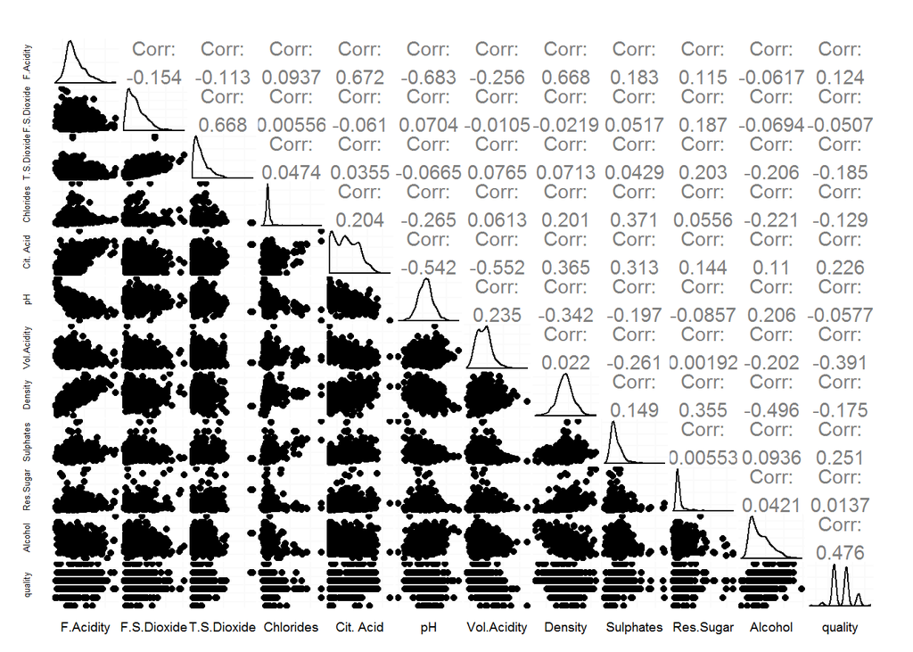

Now, concentrating on the above defined main features of interest, the plot below only provides information on *pH*, *Volatile Acidity*, *Citric Acid*, *Total Sulfur Dioxide*, *Residual Sugar*, *Alcohol* and *Quality*. Most interesting is for sure the correlation between the feartures *Alcohol*, *Volatile Acidity*, *Citric Acid* and the output variable *Quality*. There seems to be quite a weak correlation between *Total Sulfur Dioxide* and *Quality*. And almost zero correlation between *Residual Sugar* and *Quality*.

More comments on signifiant correlations are discussed in the below sections.

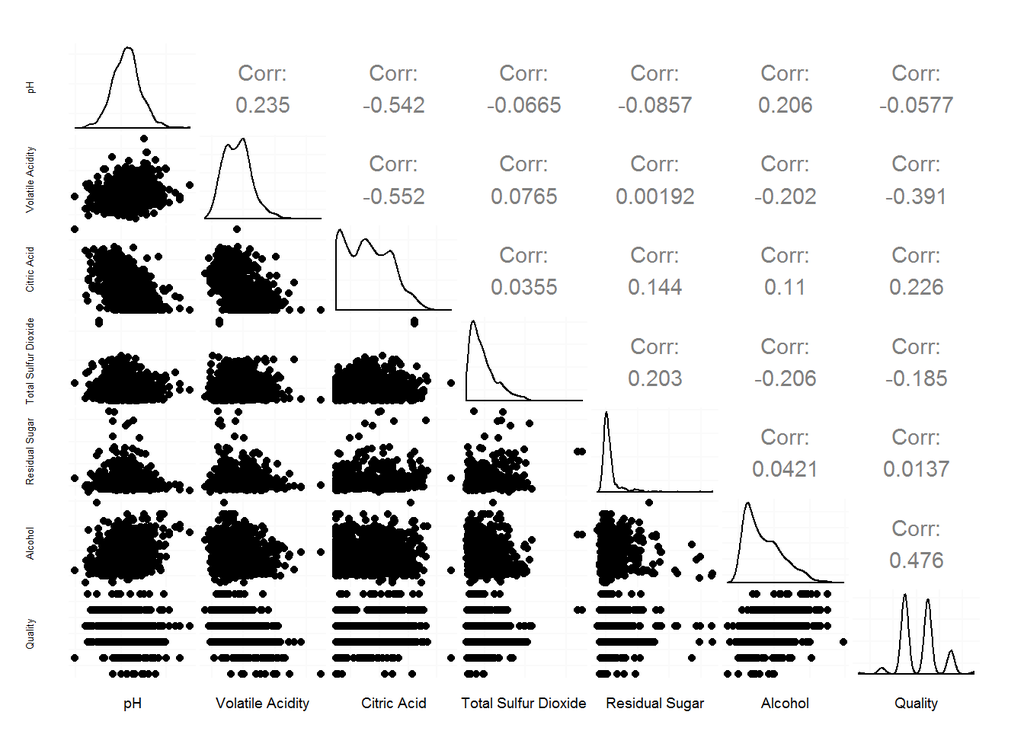

Further in this section I will focus on rather strong relationships between different features. That means, features which do have a correlation coefficient greater than 0.5 or below -0.5. Despite such scenarios, I will also focus on relationships between output feature *quality* and other features in case the correlation coefficient is greater 0.33 or below -0.33.

Also, I will do some further investigations on the main features to see how the different assumptions about their impact on *Quality* are reflected in the dataset.

#### Correlations between features

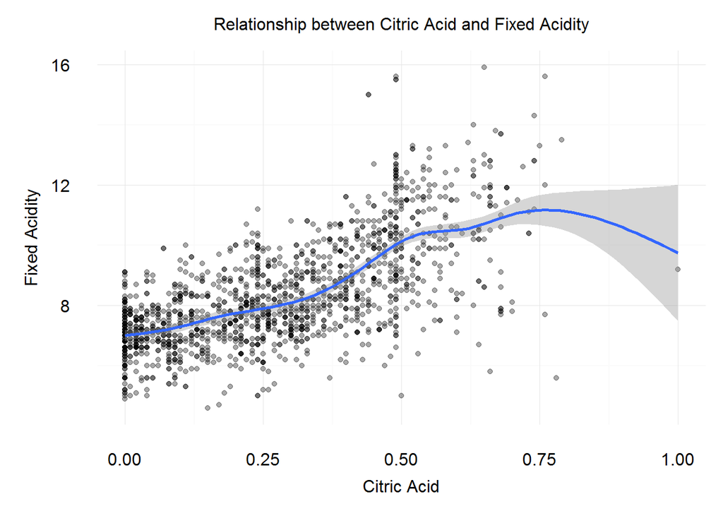

```
##
##  Pearson's product-moment correlation
##
## data:  fixed.acidity and citric.acid
## t = 36.234, df = 1597, p-value < 2.2e-16
## alternative hypothesis: true correlation is not equal to 0
## 95 percent confidence interval:
##  0.6438839 0.6977493
## sample estimates:
##       cor
## 0.6717034
```

There existis a strong positive correlation of 0.672 between *Fixed Acidity* and *Citric Acid*. It is a bit surprising that there are quite a lot wines which do have a *Citric Acid* value of 0.

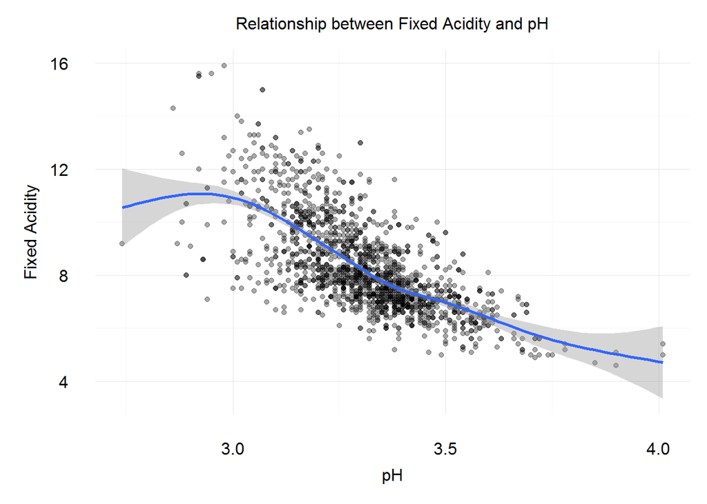

```
##
##  Pearson's product-moment correlation
##
## data:  fixed.acidity and pH
## t = -37.366, df = 1597, p-value < 2.2e-16
## alternative hypothesis: true correlation is not equal to 0
## 95 percent confidence interval:
##  -0.7082857 -0.6559174
## sample estimates:
##        cor
## -0.6829782
```

Between *Fixed Acidity* and *pH* exists a strong negative correlation of -0.683. On the lower *pH* (< 3) side we can see some really high *Fixed Acidity* values of 15 and higher, whereas for higher *pH* (> 3.75) the correspondig *Fixed Acidity* values are rather small with values between 4 and 6.

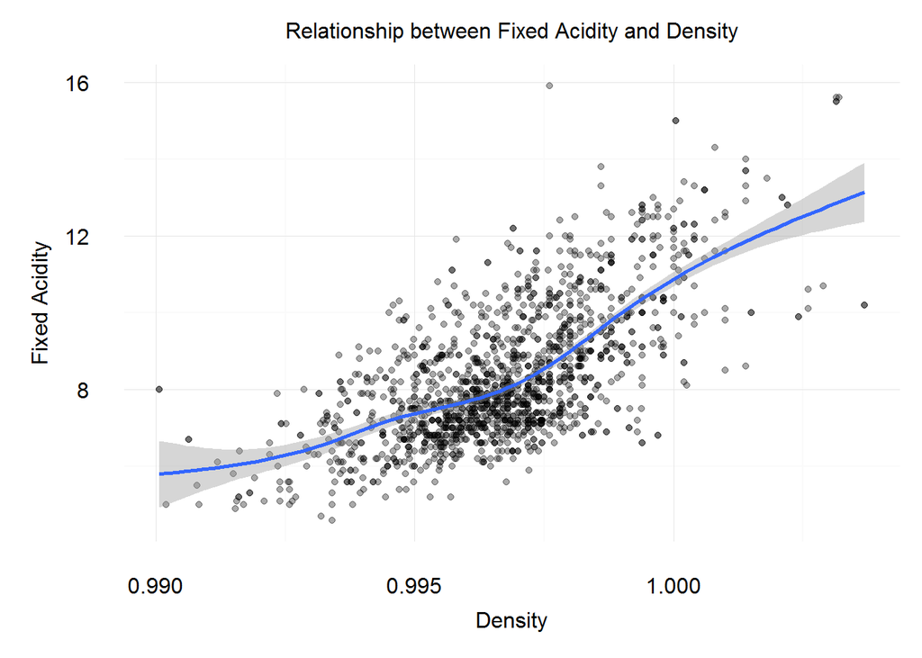

```
##
##  Pearson's product-moment correlation
##
## data:  fixed.acidity and density
## t = 35.877, df = 1597, p-value < 2.2e-16
## alternative hypothesis: true correlation is not equal to 0
## 95 percent confidence interval:
##  0.6399847 0.6943302
## sample estimates:
##       cor
## 0.6680473
```

*Density* values are increasing as the values for *Fixed Acidity* increase. There is a quite strong positive correlation of 0.668 between those two features.

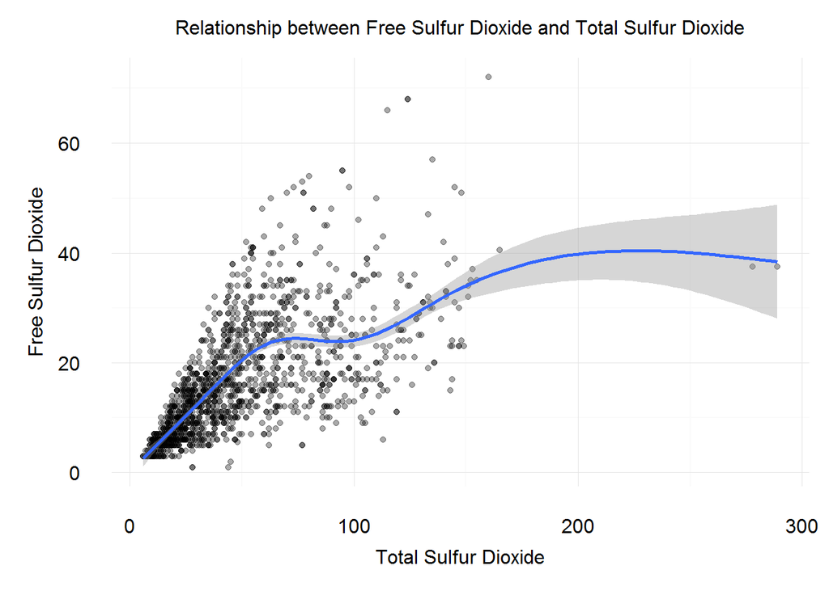

```
##
##  Pearson's product-moment correlation
##
## data:  free.sulfur.dioxide and total.sulfur.dioxide
## t = 35.84, df = 1597, p-value < 2.2e-16
## alternative hypothesis: true correlation is not equal to 0
## 95 percent confidence interval:
##  0.6395786 0.6939740
## sample estimates:
##       cor
## 0.6676665
```

Obviously, we can see a strong correlation of 0.668 between *Free Sulfur Dioxide* and *Total Sulfur Dioxide*. *Total Sulfur Dioxide* values include values for *Free Sulfur Dioxide*. However, for that reason I take a look at the ratio between the two values, named *Ratio Sulfur Dioxides*.

The following plots provide some insights on how *Ratio Sulfur Dioxides* relates to *Free Sulfur Dioxide* and *Total Sulfur Dioxide*.

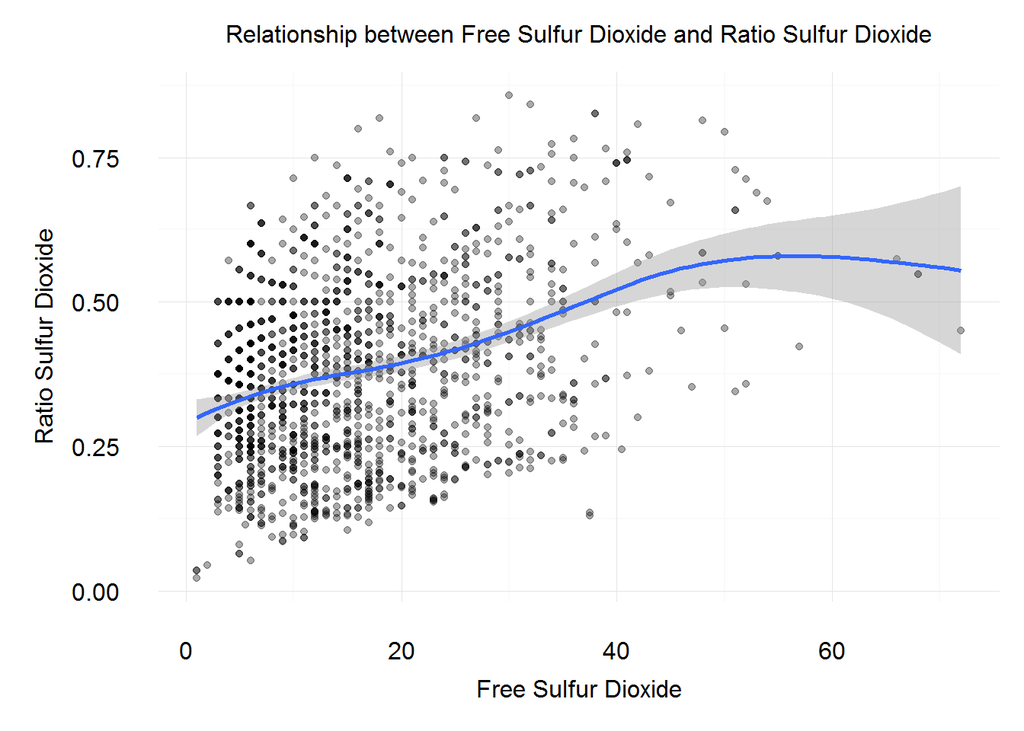

```
##
##  Pearson's product-moment correlation
##
## data:  free.sulfur.dioxide and ratio.sulfur.dioxide
## t = 13.839, df = 1597, p-value < 2.2e-16
## alternative hypothesis: true correlation is not equal to 0
## 95 percent confidence interval:
##  0.2827556 0.3703214
## sample estimates:
##       cor
## 0.3272409
```

We can see a rather small positive correlation between *Free Sulfur Dioxide* and *Ratio Sulfur Dioxide*, although the higher values (> 0.75) for *Ratio Sulfur Dioxide* are between 16 and 50 *Free Sulfur Dioxide*. Whereas the smaller values (< 0.25) for *Ratio Sulfur Dioxide* are between 1 and 40.5 *Free Sulfur Dioxide*.

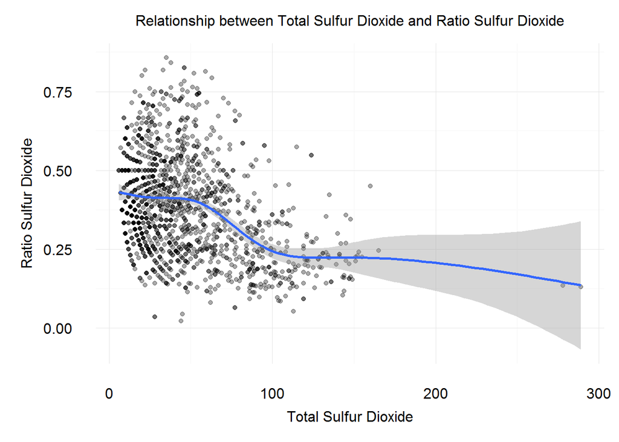

```
##
##  Pearson's product-moment correlation
##
## data:  total.sulfur.dioxide and ratio.sulfur.dioxide
## t = -15.987, df = 1597, p-value < 2.2e-16
## alternative hypothesis: true correlation is not equal to 0
## 95 percent confidence interval:
##  -0.4129372 -0.3283932
## sample estimates:
##        cor
## -0.3714349
```

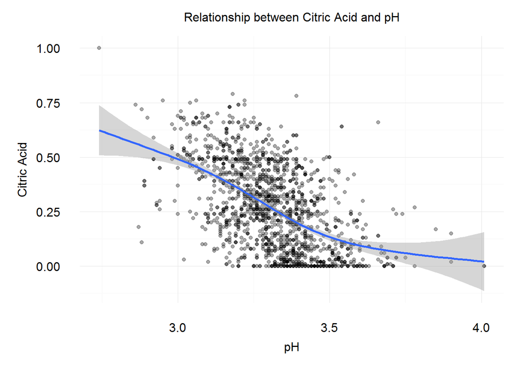

```
##
##  Pearson's product-moment correlation
##
## data:  citric.acid and pH
## t = -25.767, df = 1597, p-value < 2.2e-16
## alternative hypothesis: true correlation is not equal to 0
## 95 percent confidence interval:
##  -0.5756337 -0.5063336
## sample estimates:
##        cor
## -0.5419041
```

There is a rather strong negative correlation between *Citric Acid* and *pH* of -0.542. However, we can see quite some 0 values for *Citric Acid* which is amplifying the correlation. Another observation is that the lowest value of *pH* has the highest *Citirc Acid* values of 1, and on the other hande the highest values for *pH* has lowest *Citirc Acid* value of 0.

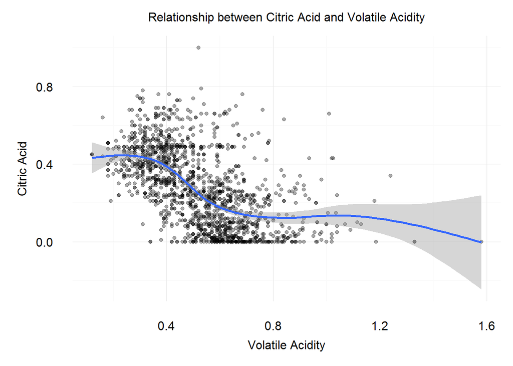

```
##
##  Pearson's product-moment correlation
##
## data:  citric.acid and volatile.acidity
## t = -26.489, df = 1597, p-value < 2.2e-16
## alternative hypothesis: true correlation is not equal to 0
## 95 percent confidence interval:
##  -0.5856550 -0.5174902
## sample estimates:
##        cor
## -0.5524957
```

Another negative correlation exists between *Citric Acid* and *Volatile Acidity*. As pointed out earlier already, quite a lot 0 values exist for *Citric Acid*.